# Music and mood

#Anxiety summary statistics by Music Effect

```r
mxmh_survey_results %>%
  filter(!is.na(`Music effects`)) %>%
  group_by(`Music effects`) %>%
  summarise(
    count = n(),
    mean_anxiety = mean(Anxiety, na.rm = TRUE),
    sd_anxiety = sd(Anxiety, na.rm = TRUE),
    median_anxiety = median(Anxiety, na.rm = TRUE),
    IQR_anxiety = IQR(Anxiety, na.rm = TRUE)
  )
```

```
## # A tibble: 3 × 6
##   `Music effects` count mean_anxiety sd_anxiety median_anxiety IQR_anxiety
##   <chr>           <int>        <dbl>      <dbl>          <dbl>       <dbl>
## 1 Improve           542         6.05       2.66              7           4
## 2 No effect         169         5.12       3.08              5           5
## 3 Worsen             17         6.76       2.61              7           3
```

Anxiety scores were lower among participants who reported that music had no effect on their mood. The No effect group had a median anxiety score of 5, compared with 7 for both the Improve and Worsen groups. The Improve and Worsen groups also had slightly smaller IQRs, although the Worsen group only contained 17 participants and should be interpreted carefully.

# Anxiety scores by reported music effect( categorical)

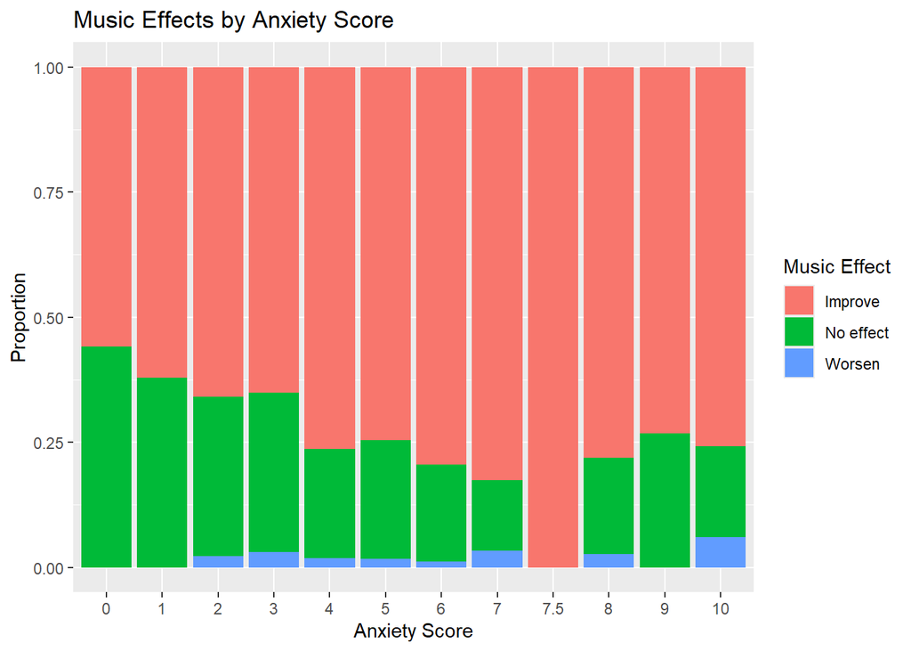

```r
mxmh_survey_results %>%
  filter(!is.na(`Music effects`)) %>%
  ggplot(aes(x = factor(Anxiety),
             fill = `Music effects`)) +
  geom_bar(position = "fill") +
  labs(title = "Music Effects by Anxiety Score",
       x = "Anxiety Score",
       y = "Proportion",
       fill = "Music Effect")
```

Music improvement was the most common response across most anxiety scores. Participants with lower anxiety scores showed a larger proportion of No effect responses, while higher anxiety scores generally showed a larger proportion reporting improvement, although the pattern is not perfectly consistent.

Insomnia Scores by Music Effect # Insomnia scores by reported music effect

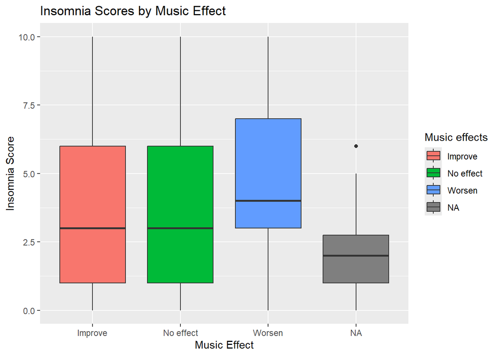

```r
ggplot(mxmh_survey_results,
       aes(x = `Music effects`,
           y = Insomnia,
           fill = `Music effects`)) +
  geom_boxplot() +
  labs(title = "Insomnia Scores by Music Effect",
       x = "Music Effect",
       y = "Insomnia Score")
```

# Insomnia scores by Music Effect, excluding missing responses

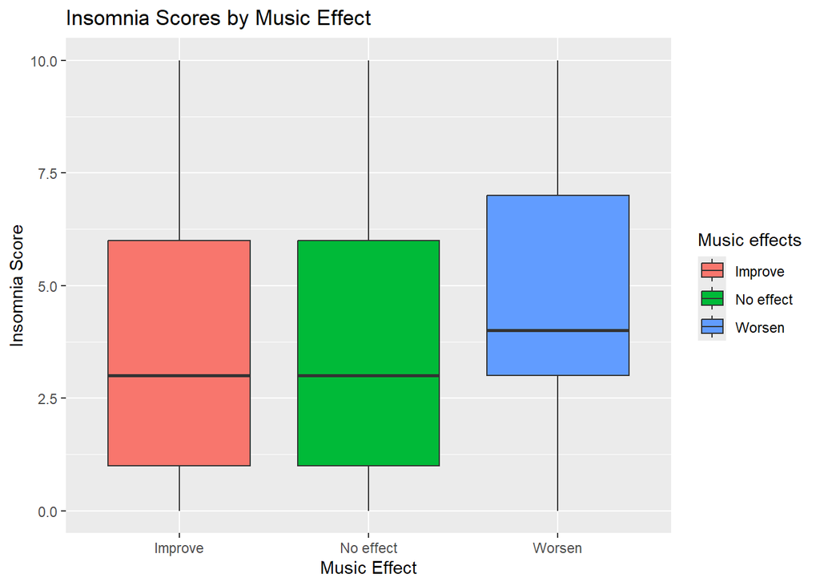

```r
mxmh_survey_results %>%
  filter(!is.na(`Music effects`)) %>%
  ggplot(aes(x = `Music effects`,
             y = Insomnia,
             fill = `Music effects`)) +
  geom_boxplot() +
  labs(title = "Insomnia Scores by Music Effect",
       x = "Music Effect",
       y = "Insomnia Score")
```

The boxplot shows that insomnia scores are very similar for participants who reported that music had no effect and those who reported that music improved their mood. Participants in the Worsen group appear to have slightly higher insomnia scores, although this group contains far fewer participants.

# Insomnia summary statistics by Music Effect

```r
mxmh_survey_results %>%
  filter(!is.na(`Music effects`)) %>%
  group_by(`Music effects`) %>%
  summarise(
    count = n(),
    mean_insomnia = mean(Insomnia, na.rm = TRUE),
    sd_insomnia = sd(Insomnia, na.rm = TRUE),
    median_insomnia = median(Insomnia, na.rm = TRUE),
    IQR_insomnia = IQR(Insomnia, na.rm = TRUE)
  )
```

```
## # A tibble: 3 × 6
##   `Music effects` count mean_insomnia sd_insomnia median_insomnia IQR_insomnia
##   <chr>           <int>         <dbl>       <dbl>           <dbl>        <dbl>
## 1 Improve           542          3.76        3.04               3            5
## 2 No effect         169          3.67        3.30               3            5
## 3 Worsen             17          4.53        2.94               4            4
```

#Insomnia scores by Music Effect(as categories)

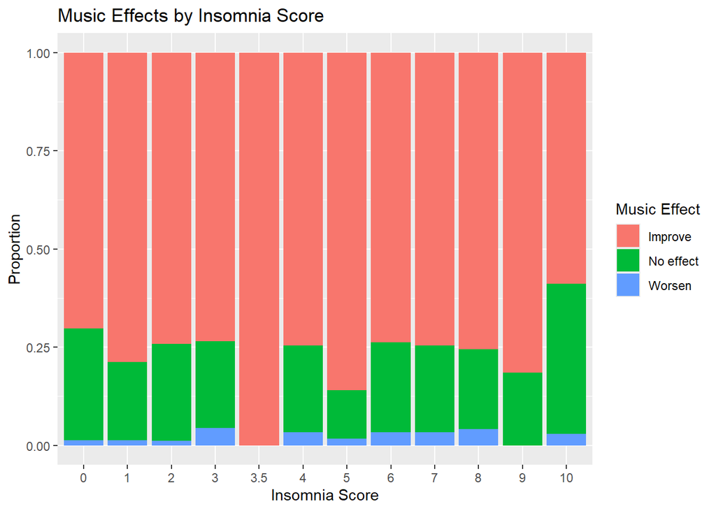

```r
mxmh_survey_results %>%
  filter(!is.na(`Music effects`)) %>%
  ggplot(aes(x = factor(Insomnia),
             fill = `Music effects`)) +
  geom_bar(position = "fill") +
  labs(title = "Music Effects by Insomnia Score",
       x = "Insomnia Score",
       y = "Proportion",
       fill = "Music Effect")
```

Music improvement was the most common response across nearly all insomnia scores. The proportions were fairly similar across most scores, with no clear increasing or decreasing pattern, suggesting that insomnia may not strongly distinguish participants’ reported music effects.

OCD Scores by Music Effect # OCD scores by reported music effect

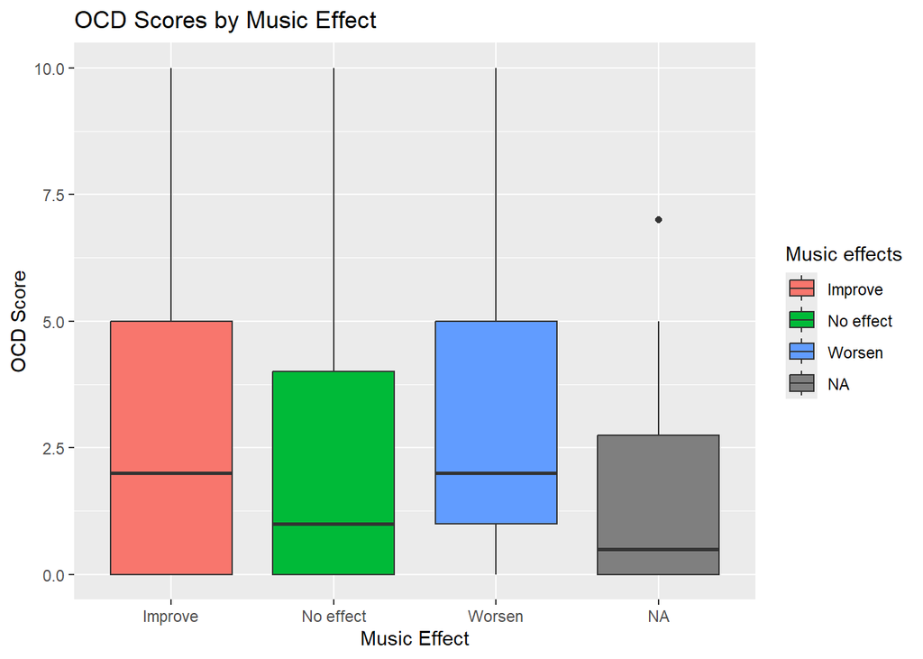

```r
ggplot(mxmh_survey_results,
       aes(x = `Music effects`,
           y = OCD,
           fill = `Music effects`)) +
  geom_boxplot() +
  labs(title = "OCD Scores by Music Effect",
       x = "Music Effect",
       y = "OCD Score")
```

# OCD scores by Music Effect, excluding missing responses

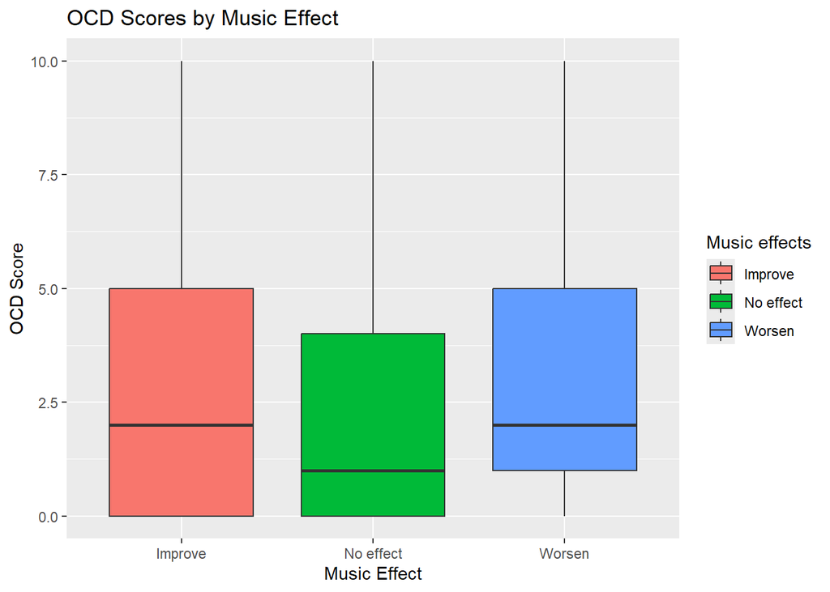

```r
mxmh_survey_results %>%
  filter(!is.na(`Music effects`)) %>%
  ggplot(aes(x = `Music effects`,
             y = OCD,
             fill = `Music effects`)) +
  geom_boxplot() +
  labs(title = "OCD Scores by Music Effect",
       x = "Music Effect",
       y = "OCD Score")
```

OCD scores look fairly similar across all three music effect groups, with the No effect group showing a slightly lower median. The large amount of overlap suggests that OCD may not strongly distinguish how participants report music affecting their mood.

# OCD summary statistics by Music Effect

```r
mxmh_survey_results %>%
  filter(!is.na(`Music effects`)) %>%
  group_by(`Music effects`) %>%
  summarise(
    count = n(),
    mean_OCD = mean(OCD, na.rm = TRUE),
    sd_OCD = sd(OCD, na.rm = TRUE),
    median_OCD = median(OCD, na.rm = TRUE),
    IQR_OCD = IQR(OCD, na.rm = TRUE)
  )
```

```
## # A tibble: 3 × 6
##   `Music effects` count mean_OCD sd_OCD median_OCD IQR_OCD
##   <chr>           <int>    <dbl>  <dbl>      <dbl>   <dbl>
## 1 Improve           542     2.72   2.83          2       5
## 2 No effect         169     2.36   2.87          1       4
## 3 Worsen             17     3.12   3.10          2       4
```

OCD scores were fairly similar across the music effect groups. The No effect group had a median of 1, while both the Improve and Worsen groups had a median of 2, suggesting that OCD may not strongly distinguish reported music effects.

# OCD scores by Music Effect (as categories)

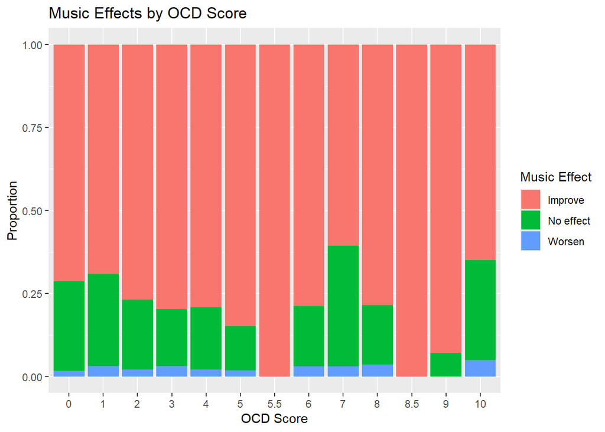

```r
mxmh_survey_results %>%
  filter(!is.na(`Music effects`)) %>%
  ggplot(aes(x = factor(OCD),
             fill = `Music effects`)) +
  geom_bar(position = "fill") +
  labs(title = "Music Effects by OCD Score",
       x = "OCD Score",
       y = "Proportion",
       fill = "Music Effect")
```

Music improvement was the most common response across nearly all OCD scores. The proportions varied across scores without a clear increasing or decreasing pattern, suggesting that OCD may not strongly distinguish participants reported music effects.

# Summary of group comparisions

Depression and anxiety showed the clearest differences across the music effect groups. Insomnia and OCD scores were more similar across the groups, suggesting that they may be less useful for predicting participants’ reported music effects. Because the Worsen group only contains 17 participants, all comparisons involving that group should be interpreted carefully.

#Exploring Other Possible Predictors Before building the model, I looked at other variables that may help predict whether participants report that music improves their mood.

Hours per Day by Music Effect # Compare listening time across Music Effect groups

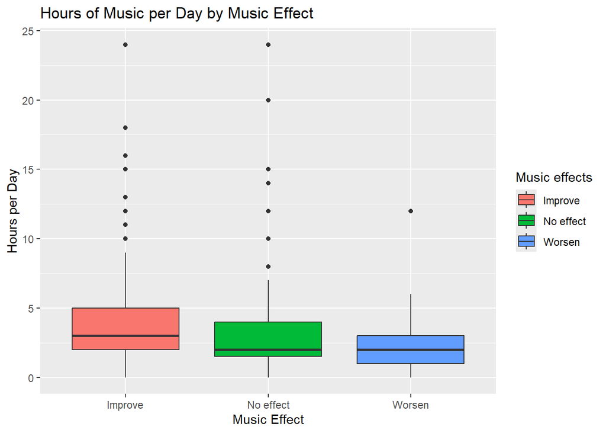

```r
mxmh_survey_results %>%
  filter(!is.na(`Music effects`)) %>%
  ggplot(aes(x = `Music effects`,
             y = `Hours per day`,
             fill = `Music effects`)) +
  geom_boxplot() +
  labs(title = "Hours of Music per Day by Music Effect",
       x = "Music Effect",
       y = "Hours per Day")
```

Participants who reported that music improved their mood appear to listen to slightly more music per day, with a median around 3 hours compared with about 2 hours for the No effect and Worsen groups. However, the groups still overlap considerably, so Hours per Day alone may not strongly distinguish reported music effects.

# Hours per Day summary statistics by Music Effect

```r
mxmh_survey_results %>%
  filter(!is.na(`Music effects`)) %>%
  group_by(`Music effects`) %>%
  summarise(
    count = n(),
    mean_hours = mean(`Hours per day`, na.rm = TRUE),
    sd_hours = sd(`Hours per day`, na.rm = TRUE),
    median_hours = median(`Hours per day`, na.rm = TRUE),
    IQR_hours = IQR(`Hours per day`, na.rm = TRUE))
```

```
## # A tibble: 3 × 6
##   `Music effects` count mean_hours sd_hours median_hours IQR_hours
##   <chr>           <int>      <dbl>    <dbl>        <dbl>     <dbl>
## 1 Improve           542       3.66     2.93            3       3
## 2 No effect         169       3.45     3.38            2       2.5
## 3 Worsen             17       2.76     2.87            2       2
```

Participants who reported that music improved their mood had a slightly higher median listening time of 3 hours per day, compared with 2 hours for both the No effect and Worsen groups. The differences are relatively small and the groups overlap, so Hours per Day may provide some information but does not strongly separate the Music Effect groups by itself.

# While Working and reported Music Effect

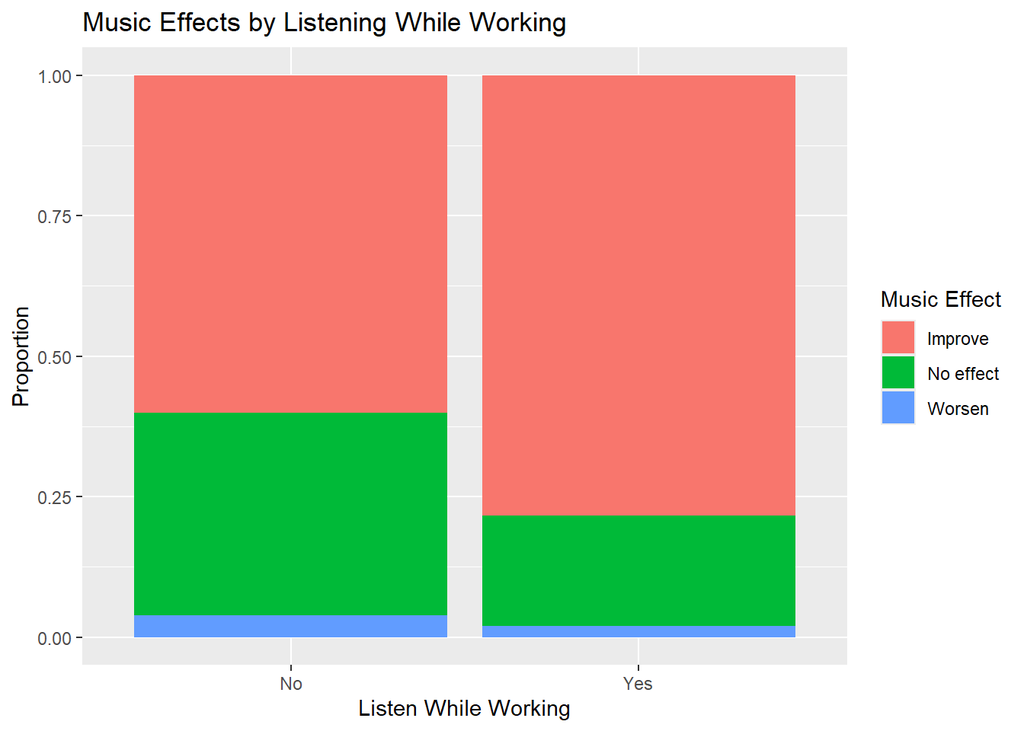

```r
mxmh_survey_results %>%
  filter(!is.na(`Music effects`),
         !is.na(`While working`)) %>%
  ggplot(aes(x = `While working`,
             fill = `Music effects`)) +
  geom_bar(position = "fill") +
  labs(title = "Music Effects by Listening While Working",
       x = "Listen While Working",
       y = "Proportion",
       fill = "Music Effect")
```

Participants who listened to music while working had a noticeably larger proportion reporting that music improved their mood compared with those who did not listen while working. Participants who did not listen while working were more likely to report that music had no effect, suggesting that listening while working may be useful to explore as a predictor of reported music effects.

# Favorite Genre and reported Music Effect

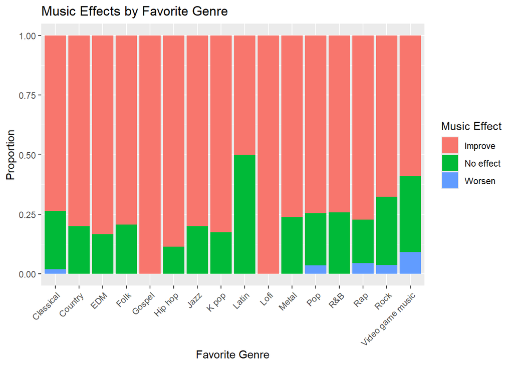

```r
mxmh_survey_results %>%
  filter(!is.na(`Music effects`)) %>%
  ggplot(aes(x = `Fav genre`,
             fill = `Music effects`)) +
  geom_bar(position = "fill") +
  labs(title = "Music Effects by Favorite Genre",
       x = "Favorite Genre",
       y = "Proportion",
       fill = "Music Effect") +
  theme(axis.text.x = element_text(angle = 45, hjust = 1))
```

#Creating Binary Music Effect Response

To prepare for binary logistic regression, I combined participants who reported No effect or Worsen into one No improvement group, while keeping Improve as its own group.

#Combine Music Effect into two groups for logistic regression

```r
mxmh_survey_results <- mxmh_survey_results %>%
  mutate(
    `Music improvement` = case_when(
      `Music effects` == "Improve" ~ "Improve",
      `Music effects` %in% c("No effect", "Worsen") ~ "No improvement",
      TRUE ~ NA_character_
    )
  )
```

# Check the new response groups

```r
table(mxmh_survey_results$`Music improvement`,
      useNA = "ifany")
```

```
##
##        Improve No improvement           <NA>
##            542            186              8
```

The new response variable contains 542 participants in the Improve group and 186 in the No improvement group, with 8 missing responses. This binary outcome will be used for the logistic regression model.

#Binary Logistic Regression

I started with Depression as the first predictor because Depression showed noticeable differences across the Music Effect groups during the exploratory analysis.

# Set the new response as a factor

```r
mxmh_survey_results$`Music improvement` <-
  factor(mxmh_survey_results$`Music improvement`,
         levels = c("No improvement", "Improve"))
```

# First binary logistic regression using Depression

```r
model_1 <- glm(
  `Music improvement` ~ Depression,
  data = mxmh_survey_results,
  family = binomial)
summary(model_1)
```

```
##
## Call:
## glm(formula = `Music improvement` ~ Depression, family = binomial,
##     data = mxmh_survey_results)
##
## Coefficients:
##             Estimate Std. Error z value Pr(>|z|)
## (Intercept)  0.95140    0.15701   6.059 1.37e-09 ***
## Depression   0.02488    0.02813   0.884    0.376
## ---
## Signif. codes:  0 '***' 0.001 '**' 0.01 '*' 0.05 '.' 0.1 ' ' 1
##
## (Dispersion parameter for binomial family taken to be 1)
##
##     Null deviance: 827.43  on 727  degrees of freedom
## Residual deviance: 826.65  on 726  degrees of freedom
##   (8 observations deleted due to missingness)
## AIC: 830.65
##
## Number of Fisher Scoring iterations: 4
```

In the first logistic regression model, Depression was not a significant predictor of whether participants reported music improving their mood (p = 0.376).

#Model 2: Adding Anxiety Since Anxiety also showed differences across the Music improvement groups, I added Anxiety to the Depression model to see whether it provides additional information for predicting reported music improvement.

```r
model_2 <- glm(
  `Music improvement` ~ Depression + Anxiety,
  data = mxmh_survey_results,
  family = binomial)
summary(model_2)
```

```
##
## Call:
## glm(formula = `Music improvement` ~ Depression + Anxiety, family = binomial,
##     data = mxmh_survey_results)
##
## Coefficients:
##             Estimate Std. Error z value Pr(>|z|)
## (Intercept)  0.56185    0.19410   2.895  0.00380 **
## Depression  -0.03151    0.03324  -0.948  0.34315
## Anxiety      0.11601    0.03578   3.242  0.00119 **
## ---
## Signif. codes:  0 '***' 0.001 '**' 0.01 '*' 0.05 '.' 0.1 ' ' 1
##
## (Dispersion parameter for binomial family taken to be 1)
##
##     Null deviance: 827.43  on 727  degrees of freedom
## Residual deviance: 816.00  on 725  degrees of freedom
##   (8 observations deleted due to missingness)
## AIC: 822
##
## Number of Fisher Scoring iterations: 4
```

Model 2 showed that Anxiety was a statistically significant predictor of reported music improvement (p = 0.001), while Depression remained non-significant (p = 0.343). Higher anxiety scores were associated with higher odds of reporting Improve rather than No improvement.

# Model 3: Depression + Anxiety + While Working

Since listening while working showed a noticeable difference in reported music improvement, I added While Working to the Depression and Anxiety model.

```r
model_3 <- glm(
  `Music improvement` ~ Depression + Anxiety + `While working`,
  data = mxmh_survey_results,
  family = binomial)
summary(model_3)
```

```
##
## Call:
## glm(formula = `Music improvement` ~ Depression + Anxiety + `While working`,
##     family = binomial, data = mxmh_survey_results)
##
## Coefficients:
##                    Estimate Std. Error z value Pr(>|z|)
## (Intercept)        -0.06772    0.24192  -0.280 0.779547
## Depression         -0.04419    0.03373  -1.310 0.190140
## Anxiety             0.12181    0.03619   3.366 0.000762 ***
## `While working`Yes  0.87547    0.19614   4.464 8.06e-06 ***
## ---
## Signif. codes:  0 '***' 0.001 '**' 0.01 '*' 0.05 '.' 0.1 ' ' 1
##
## (Dispersion parameter for binomial family taken to be 1)
##
##     Null deviance: 824.11  on 725  degrees of freedom
## Residual deviance: 792.62  on 722  degrees of freedom
##   (10 observations deleted due to missingness)
## AIC: 800.62
##
## Number of Fisher Scoring iterations: 4
```

Model 3 showed that Anxiety and listening while working were statistically significant predictors of reported music improvement. Higher anxiety scores and listening to music while working were associated with higher odds of reporting Improve, while Depression remained non-significant.

#Model 4: Adding Hours per Day Since Hours per Day showed a small difference across the Music Effect groups, I added it to the model to see whether listening time provides additional information for predicting music improvement.

```r
model_4 <- glm( `Music improvement` ~ Depression + Anxiety + `While working` + `Hours per day`,
  data = mxmh_survey_results,
  family = binomial)
summary(model_4)
```

```
##
## Call:
## glm(formula = `Music improvement` ~ Depression + Anxiety + `While working` +
##     `Hours per day`, family = binomial, data = mxmh_survey_results)
##
## Coefficients:
##                    Estimate Std. Error z value Pr(>|z|)
## (Intercept)        -0.04896    0.24673  -0.198 0.842700
## Depression         -0.04318    0.03382  -1.277 0.201717
## Anxiety             0.12164    0.03619   3.361 0.000777 ***
## `While working`Yes  0.89972    0.20631   4.361  1.3e-05 ***
## `Hours per day`    -0.01157    0.03011  -0.384 0.700836
## ---
## Signif. codes:  0 '***' 0.001 '**' 0.01 '*' 0.05 '.' 0.1 ' ' 1
##
## (Dispersion parameter for binomial family taken to be 1)
##
##     Null deviance: 824.11  on 725  degrees of freedom
## Residual deviance: 792.48  on 721  degrees of freedom
##   (10 observations deleted due to missingness)
## AIC: 802.48
##
## Number of Fisher Scoring iterations: 4
```

Model 4 showed that Anxiety and listening while working remained statistically significant predictors of reported music improvement. Depression and Hours per Day were not significant, suggesting that listening time did not add much predictive information after accounting for the other variables.

# Comparing the Logistic Regression Models

```r
AIC(model_1, model_2, model_3, model_4)
```

```
##         df      AIC
## model_1  2 830.6496
## model_2  3 822.0016
## model_3  4 800.6245
## model_4  5 802.4789
```

Model 3 had a lower AIC than Model 4 (800.62 compared with 802.48), suggesting that adding Hours per Day did not improve the model enough to justify the additional predictor. Combined with its non-significant p-value, this suggests that Hours per Day may not be useful to keep in the final model.

Model 5: Anxiety and Listening While Working Since Anxiety and While Working remained significant in the previous models, I created a simpler model using only these two predictors.

# Model 5: Anxiety + While Working

```r
model_5 <- glm(
  `Music improvement` ~ Anxiety + `While working`,
  data = mxmh_survey_results,
  family = binomial)
summary(model_5)
```

```
##
## Call:
## glm(formula = `Music improvement` ~ Anxiety + `While working`,
##     family = binomial, data = mxmh_survey_results)
##
## Coefficients:
##                    Estimate Std. Error z value Pr(>|z|)
## (Intercept)        -0.12940    0.23718  -0.546  0.58537
## Anxiety             0.09714    0.03073   3.161  0.00157 **
## `While working`Yes  0.86371    0.19549   4.418 9.95e-06 ***
## ---
## Signif. codes:  0 '***' 0.001 '**' 0.01 '*' 0.05 '.' 0.1 ' ' 1
##
## (Dispersion parameter for binomial family taken to be 1)
##
##     Null deviance: 824.11  on 725  degrees of freedom
## Residual deviance: 794.35  on 723  degrees of freedom
##   (10 observations deleted due to missingness)
## AIC: 800.35
##
## Number of Fisher Scoring iterations: 4
```

Model 5 showed that Anxiety and listening while working were both statistically significant predictors of reported music improvement. Model 5 also had a slightly lower AIC than Model 3, suggesting that removing Depression created a simpler model without the reducing model fit.

#Comparing Model 3 and Model 5

```r
AIC(model_3, model_5)
```

```
##         df      AIC
## model_3  4 800.6245
## model_5  3 800.3498
```

Model 3 and Model 5 had very similar AIC values (800.62 and 800.35). Since Model 5 uses fewer predictors and Depression was not statistically significant in Model 3, Model 5 provides a simpler model with similar fit.

#Training and Testing the Models Before fitting the final prediction models, I created a separate modeling dataset using the regrouped Music improvement response.

# Creating the modeling dataset

```r
model_data <- mxmh_survey_results %>%
  filter(!is.na(`Music improvement`))
table(model_data$`Music improvement`)
```

```
##
## No improvement        Improve
##            186            542
```

The modeling dataset contains 542 participants in the Improve group and 186 participants in the No improvement group, for a total of 728 participants.

80/20 Training and Testing Split # Split modeling data into 80% training and 20% testing

```r
set.seed(123)
train_index <- sample(
  1:nrow(model_data),
  size = 0.80 * nrow(model_data))

train_data <- model_data[train_index, ]

test_data <- model_data[-train_index, ]
# Check training and testing sizes

nrow(train_data)
```

```
## [1] 582
```

```r
nrow(test_data)
```

```
## [1] 146
```

```r
table(train_data$`Music improvement`)
```

```
##
## No improvement        Improve
##            144            438
```

```r
table(test_data$`Music improvement`)
```

```
##
## No improvement        Improve
##             42            104
```

The cleaned modeling data were randomly split into 582 training observations and 146 testing observations, using approximately 80% of the data for model development and 20% for evaluating predictions on unseen observations.

# Full logistic model using training data only

```r
full_model <- glm(
  `Music improvement` ~ Age + `Hours per day` + `While working` +
    `Fav genre` + Anxiety + Depression + Insomnia + OCD,
  data = train_data,
  family = binomial
)

summary(full_model)
```

```
##
## Call:
## glm(formula = `Music improvement` ~ Age + `Hours per day` + `While working` +
##     `Fav genre` + Anxiety + Depression + Insomnia + OCD, family = binomial,
##     data = train_data)
##
## Coefficients:
##                               Estimate Std. Error z value Pr(>|z|)
## (Intercept)                  1.545e-02  5.095e-01   0.030   0.9758
## Age                         -1.004e-02  8.571e-03  -1.172   0.2412
## `Hours per day`             -1.608e-03  3.555e-02  -0.045   0.9639
## `While working`Yes           1.043e+00  2.440e-01   4.274 1.92e-05 ***
## `Fav genre`Country           7.688e-01  7.400e-01   1.039   0.2988
## `Fav genre`EDM               8.126e-01  6.239e-01   1.302   0.1928
## `Fav genre`Folk              3.055e-01  6.786e-01   0.450   0.6526
## `Fav genre`Gospel            1.581e+01  1.159e+03   0.014   0.9891
## `Fav genre`Hip hop           8.096e-01  6.624e-01   1.222   0.2216
## `Fav genre`Jazz              6.397e-01  8.738e-01   0.732   0.4641
## `Fav genre`K pop             1.956e-01  7.390e-01   0.265   0.7912
## `Fav genre`Latin             1.452e+01  2.400e+03   0.006   0.9952
## `Fav genre`Lofi              1.532e+01  8.438e+02   0.018   0.9855
## `Fav genre`Metal             2.725e-01  4.700e-01   0.580   0.5621
## `Fav genre`Pop              -2.544e-01  4.324e-01  -0.588   0.5563
## `Fav genre`R&B              -1.993e-01  5.440e-01  -0.366   0.7141
## `Fav genre`Rap               3.923e-01  6.891e-01   0.569   0.5691
## `Fav genre`Rock             -1.662e-01  4.028e-01  -0.413   0.6798
## `Fav genre`Video game music -5.244e-01  5.116e-01  -1.025   0.3053
## Anxiety                      1.507e-01  4.615e-02   3.265   0.0011 **
## Depression                  -5.529e-02  4.157e-02  -1.330   0.1835
## Insomnia                    -2.342e-02  3.653e-02  -0.641   0.5214
## OCD                          4.813e-03  3.998e-02   0.120   0.9042
## ---
## Signif. codes:  0 '***' 0.001 '**' 0.01 '*' 0.05 '.' 0.1 ' ' 1
##
## (Dispersion parameter for binomial family taken to be 1)
##
##     Null deviance: 650.1  on 579  degrees of freedom
## Residual deviance: 593.5  on 557  degrees of freedom
##   (2 observations deleted due to missingness)
## AIC: 639.5
##
## Number of Fisher Scoring iterations: 15
```

In the full training model, Anxiety and listening while working were statistically significant predictors of reported music improvement. Age, Hours per Day, Depression, Insomnia, OCD, and Favorite Genre did not show clear individual effects in this model.

Backward Selection Some predictor variables contained missing values, so I created a complete version of the training data to make sure each model being compared used the same participants.

```r
train_complete <- train_data %>%
  filter(
    !is.na(Age),
    !is.na(`Hours per day`),
    !is.na(`While working`),
    !is.na(`Fav genre`),
    !is.na(Anxiety),
    !is.na(Depression),
    !is.na(Insomnia),
    !is.na(OCD)
  )

nrow(train_complete)
```

```
## [1] 580
```

# Refit full model using complete training data

```r
full_model_complete <- glm(
  `Music improvement` ~ Age + `Hours per day` + `While working` +
    `Fav genre` + Anxiety + Depression + Insomnia + OCD,
  data = train_complete,
  family = binomial
)
# Perform backward selection

backward_model <- step(
  full_model_complete,
  direction = "backward"
)
```

```
## Start:  AIC=639.5
## `Music improvement` ~ Age + `Hours per day` + `While working` +
##     `Fav genre` + Anxiety + Depression + Insomnia + OCD
##
##                   Df Deviance    AIC
## - `Fav genre`     15   613.75 629.75
## - `Hours per day`  1   593.50 637.50
## - OCD              1   593.51 637.51
## - Insomnia         1   593.91 637.91
## - Age              1   594.85 638.85
## - Depression       1   595.28 639.28
## <none>                 593.50 639.50
## - Anxiety          1   604.38 648.38
## - `While working`  1   611.55 655.55
##
## Step:  AIC=629.75
## `Music improvement` ~ Age + `Hours per day` + `While working` +
##     Anxiety + Depression + Insomnia + OCD
##
##                   Df Deviance    AIC
## - OCD              1   613.75 627.75
## - `Hours per day`  1   613.93 627.93
## - Insomnia         1   614.04 628.04
## - Depression       1   615.01 629.01
## - Age              1   615.09 629.09
## <none>                 613.75 629.75
## - Anxiety          1   624.09 638.09
## - `While working`  1   629.78 643.78
##
## Step:  AIC=627.75
## `Music improvement` ~ Age + `Hours per day` + `While working` +
##     Anxiety + Depression + Insomnia
##
##                   Df Deviance    AIC
## - `Hours per day`  1   613.93 625.93
## - Insomnia         1   614.04 626.04
## - Depression       1   615.02 627.02
## - Age              1   615.11 627.11
## <none>                 613.75 627.75
## - Anxiety          1   625.05 637.05
```

[output cut: 25 more lines]

```
## `Music improvement` ~ `While working` + Anxiety + Depression
##
##                   Df Deviance    AIC
## - Depression       1   617.15 623.15
## <none>                 615.61 623.61
## - Anxiety          1   628.36 634.36
## - `While working`  1   635.44 641.44
##
## Step:  AIC=623.15
## `Music improvement` ~ `While working` + Anxiety
##
##                   Df Deviance    AIC
## <none>                 617.15 623.15
## - Anxiety          1   628.87 632.87
## - `While working`  1   636.82 640.82
```

```r
summary(backward_model)
```

```
##
## Call:
## glm(formula = `Music improvement` ~ `While working` + Anxiety,
##     family = binomial, data = train_complete)
##
## Coefficients:
##                    Estimate Std. Error z value Pr(>|z|)
## (Intercept)        -0.32080    0.26751  -1.199 0.230447
## `While working`Yes  0.99713    0.22132   4.505 6.63e-06 ***
## Anxiety             0.11908    0.03491   3.411 0.000648 ***
## ---
## Signif. codes:  0 '***' 0.001 '**' 0.01 '*' 0.05 '.' 0.1 ' ' 1
##
## (Dispersion parameter for binomial family taken to be 1)
##
##     Null deviance: 650.10  on 579  degrees of freedom
## Residual deviance: 617.15  on 577  degrees of freedom
## AIC: 623.15
##
## Number of Fisher Scoring iterations: 4
```

Backward selection reduced the full training model to Anxiety and Listening While Working. Both predictors remained statistically significant, suggesting that these two variables provided the most useful information for predicting reported music improvement among the predictors included in the full model.

#Evaluating Model Performance I evaluated the backward-selected model using a confusion matrix to compare the model’s predicted classifications with the actual Music improvement responses.

```r
library(caret)
```

#testing observations

```r
test_complete <- test_data %>%
  filter(
    !is.na(Anxiety),
    !is.na(`While working`)
  )
```

# Generate predicted probabilities

```r
pred <- predict(
  backward_model,
  test_complete,
  type = "response"
)
# Classify predicted probabilities as Improve (1) or No improvement (0)

pred_num <- ifelse(
  pred > 0.5,
  1,
  0
)

pred_num <- factor(
  pred_num,
  levels = c(0, 1)
)
# Convert the actual Music improvement responses to 0/1

actual_num <- ifelse(
  test_complete$`Music improvement` == "Improve",
  1,
  0)

actual_num <- factor(
  actual_num,
  levels = c(0, 1)
)
# Evaluate model performance

confusionMatrix(
  pred_num,
  actual_num,
  positive = "1"
)
```

```
## Confusion Matrix and Statistics
##
##           Reference
## Prediction   0   1
##          0   1   0
##          1  40 104
##
##                Accuracy : 0.7241
##                  95% CI : (0.6438, 0.795)
##     No Information Rate : 0.7172
##     P-Value [Acc > NIR] : 0.4686
##
##                   Kappa : 0.0346
##
##  Mcnemar's Test P-Value : 6.984e-10
##
##             Sensitivity : 1.00000
##             Specificity : 0.02439
##          Pos Pred Value : 0.72222
##          Neg Pred Value : 1.00000
##              Prevalence : 0.71724
##          Detection Rate : 0.71724
##    Detection Prevalence : 0.99310
##       Balanced Accuracy : 0.51220
##
##        'Positive' Class : 1
##
```

The model had an overall accuracy of 72.4%, but the confusion matrix showed that this value does not fully represent its predictive performance. Sensitivity was 100%, meaning the model correctly classified all participants who reported Improve. However, specificity was only 2.4%, meaning the model correctly classified only 1 of the 41 participants who reported No improvement. The balanced accuracy was 51.2%, showing that the model performed very differently across the two response groups.

The No Information Rate was 71.7%, which is very close to the model’s 72.4% accuracy. This suggests that the model provides little improvement over simply predicting the majority Improve category for nearly every participant.

#Full Model Performance on Testing Data I evaluated the full logistic regression model on the testing data using the same confusion matrix approach so its predictive performance could be compared with the backward-selected model.

```r
test_full_complete <- test_data %>%
  filter(
    !is.na(Age),
    !is.na(`Hours per day`),
    !is.na(`While working`),
    !is.na(`Fav genre`),
    !is.na(Anxiety),
    !is.na(Depression),
    !is.na(Insomnia),
    !is.na(OCD)
  )

nrow(test_full_complete)
```

```
## [1] 145
```

# Generate predicted probabilities from the full model

```r
full_pred <- predict(
  full_model_complete,
  test_full_complete,
  type = "response"
)

# Converting predicted probabilities into 0/1 classifications

full_pred_num <- ifelse(
  full_pred > 0.5,
  1,
  0)

full_pred_num <- factor(
  full_pred_num,
  levels = c(0, 1)
)
# Convert actual responses into 0/1

full_actual_num <- ifelse(
  test_full_complete$`Music improvement` == "Improve",
  1,
  0
)

full_actual_num <- factor(
  full_actual_num,
  levels = c(0, 1)
)
```

# Evaluate full model performance

```r
confusionMatrix(
  full_pred_num,
  full_actual_num,
  positive = "1")
```

```
## Confusion Matrix and Statistics
##
##           Reference
## Prediction  0  1
##          0  3  5
##          1 38 99
##
##                Accuracy : 0.7034
##                  95% CI : (0.622, 0.7764)
##     No Information Rate : 0.7172
##     P-Value [Acc > NIR] : 0.6813
##
##                   Kappa : 0.0332
##
##  Mcnemar's Test P-Value : 1.061e-06
##
##             Sensitivity : 0.95192
##             Specificity : 0.07317
##          Pos Pred Value : 0.72263
##          Neg Pred Value : 0.37500
##              Prevalence : 0.71724
##          Detection Rate : 0.68276
##    Detection Prevalence : 0.94483
##       Balanced Accuracy : 0.51255
##
##        'Positive' Class : 1
##
```

The full logistic regression model had an overall test accuracy of 70.3%. Its sensitivity was 95.2%, meaning it correctly identified 99 of the 104 participants who reported Improve. Its specificity was only 7.3%, meaning it correctly identified 3 of the 41 participants who reported No improvement. The balanced accuracy was 51.3%, showing that the full model also struggled to distinguish the two response groups.

Since both logistic regression models had difficulty distinguishing the No improvement group, I explored a Random Forest model using the default settings to see whether it improved predictive performance.

```r
library(ranger)
```

# Create Random Forest training data with simpler column names

```r
rf_train <- train_complete %>%
  select(
    `Music improvement`,
    Age,
    `Hours per day`,
    `While working`,
    `Fav genre`,
    Anxiety,
    Depression,
    Insomnia,
    OCD
  ) %>%
  rename(
    Music_improvement = `Music improvement`,
    Hours_per_day = `Hours per day`,
    While_working = `While working`,
    Fav_genre = `Fav genre`
  )
```

# Fit Random Forest using training data

```r
set.seed(123)

rf_model <- ranger(
  Music_improvement ~ Age + Hours_per_day + While_working +
    Fav_genre + Anxiety + Depression + Insomnia + OCD,
  data = rf_train,
  respect.unordered.factors = "order"
)
```

```r
rf_model
```

```
## Ranger result
##
## Call:
##  ranger(Music_improvement ~ Age + Hours_per_day + While_working +      Fav_genre + Anxiety + Depression + Insomnia + OCD, data = rf_train,      respect.unordered.factors = "order")
##
## Type:                             Classification
## Number of trees:                  500
## Sample size:                      580
## Number of independent variables:  8
## Mtry:                             2
## Target node size:                 1
## Variable importance mode:         none
## Splitrule:                        gini
## OOB prediction error:             25.52 %
```

Random Forest Performance on Testing Data I evaluated the Random Forest model on the testing data to compare its predictive performance with the logistic regression models.

# Preparing testing data for Random Forest

```r
rf_test <- test_full_complete %>%
  select(
    `Music improvement`,
    Age,
    `Hours per day`,
    `While working`,
    `Fav genre`,
    Anxiety,
    Depression,
    Insomnia,
    OCD
  ) %>%
  rename(
    Music_improvement = `Music improvement`,
    Hours_per_day = `Hours per day`,
    While_working = `While working`,
    Fav_genre = `Fav genre`
  )
```

Random Forest Performance on Testing Data I evaluated the Random Forest model on the testing data to see how well it classified new observations.

#Testing data

```r
rf_test <- test_full_complete %>%
  select(
    `Music improvement`,
    Age,
    `Hours per day`,
    `While working`,
    `Fav genre`,
    Anxiety,
    Depression,
    Insomnia,
    OCD
  ) %>%
  rename(
    Music_improvement = `Music improvement`,
    Hours_per_day = `Hours per day`,
    While_working = `While working`,
    Fav_genre = `Fav genre`
  )
```

# Predict the testing observations

```r
rf_pred <- predict(
  rf_model,
  data = rf_test)
rf_pred$predictions
```

```
##   [1] Improve        Improve        Improve        Improve        Improve
##   [6] Improve        Improve        Improve        Improve        Improve
##  [11] Improve        Improve        Improve        Improve        Improve
##  [16] Improve        Improve        Improve        Improve        Improve
##  [21] Improve        Improve        Improve        Improve        Improve
##  [26] Improve        No improvement Improve        Improve        Improve
##  [31] Improve        Improve        Improve        Improve        Improve
##  [36] Improve        Improve        No improvement Improve        Improve
##  [41] Improve        Improve        No improvement Improve        Improve
##  [46] Improve        Improve        No improvement Improve        Improve
##  [51] Improve        Improve        Improve        Improve        Improve
##  [56] Improve        Improve        Improve        Improve        Improve
##  [61] Improve        Improve        Improve        Improve        Improve
##  [66] Improve        Improve        Improve        Improve        Improve
##  [71] Improve        Improve        Improve        Improve        Improve
##  [76] Improve        Improve        Improve        Improve        Improve
##  [81] No improvement Improve        Improve        Improve        Improve
##  [86] Improve        Improve        Improve        Improve        Improve
##  [91] No improvement Improve        Improve        Improve        No improvement
##  [96] Improve        Improve        Improve        Improve        Improve
## [101] Improve        Improve        Improve        Improve        Improve
## [106] Improve        Improve        Improve        Improve        Improve
## [111] Improve        Improve        Improve        No improvement Improve
## [116] Improve        Improve        No improvement No improvement Improve
## [121] Improve        Improve        Improve        Improve        Improve
## [126] Improve        Improve        Improve        Improve        Improve
## [131] Improve        Improve        Improve        No improvement Improve
## [136] Improve        Improve        Improve        Improve        Improve
## [141] Improve        Improve        Improve        Improve        Improve
## Levels: No improvement Improve
```

# Random Forest Confusion Matrix

```r
rf_actual <- factor(
  rf_test$Music_improvement,
  levels = c("No improvement", "Improve")
)

rf_predictions <- factor(
  rf_pred$predictions,
  levels = c("No improvement", "Improve")
)

confusionMatrix(
  rf_predictions,
  rf_actual,
  positive = "Improve"
)
```

```
## Confusion Matrix and Statistics
##
##                 Reference
## Prediction       No improvement Improve
##   No improvement              2       9
##   Improve                    39      95
##
##                Accuracy : 0.669
##                  95% CI : (0.586, 0.7448)
##     No Information Rate : 0.7172
##     P-Value [Acc > NIR] : 0.915
##
##                   Kappa : -0.0485
##
##  Mcnemar's Test P-Value : 2.842e-05
##
##             Sensitivity : 0.91346
##             Specificity : 0.04878
##          Pos Pred Value : 0.70896
##          Neg Pred Value : 0.18182
##              Prevalence : 0.71724
##          Detection Rate : 0.65517
##    Detection Prevalence : 0.92414
##       Balanced Accuracy : 0.48112
##
##        'Positive' Class : Improve
##
```

The default Random Forest had an overall test accuracy of 66.9%, sensitivity of 91.3%, specificity of 4.9%, and balanced accuracy of 48.1%. It correctly identified 95 of 104 Improve cases but only 2 of 41 No improvement cases. Therefore, the default Random Forest did not improve classification performance compared with the logistic regression models and continued to struggle with the No improvement group.